# XCO2 - Aquisição de dados de XCO2

filtrando os outliers.

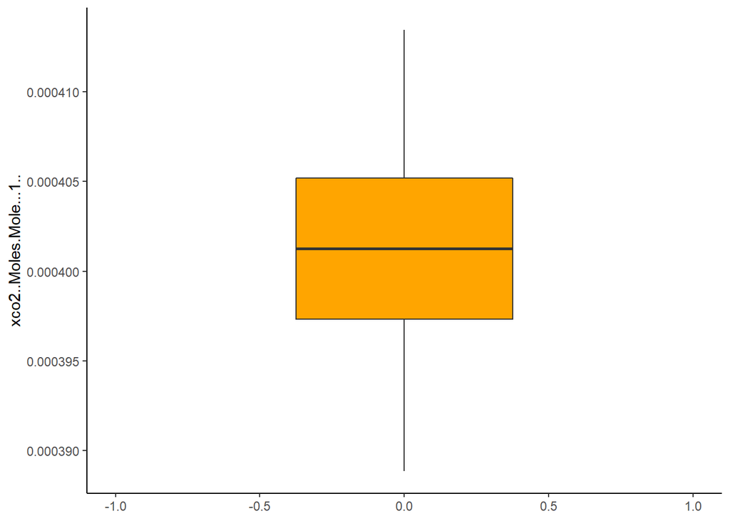

```r
oco_2 %>%
  filter(point_in_pol, xco2..Moles.Mole...1.. > limites_outlier(oco_2$xco2..Moles.Mole...1..)[1] &
           xco2..Moles.Mole...1.. < limites_outlier(oco_2$xco2..Moles.Mole...1..)[2]) %>%
  ggplot(aes(y=xco2..Moles.Mole...1..))+
  geom_boxplot(fill="orange",outlier.colour = "red")+
  coord_cartesian(xlim=c(-1,1))+
  theme_classic()
```

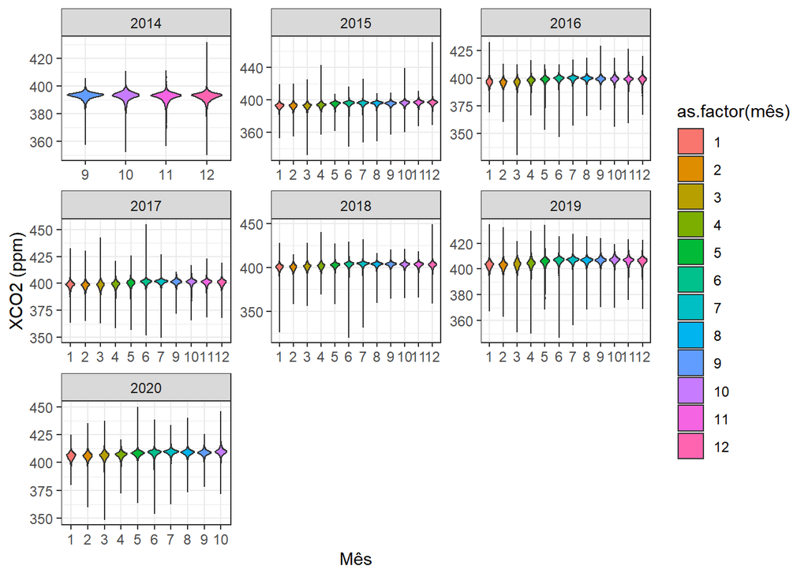

```r
oco_2 %>%
  mutate(ano_mes = paste0(ano,mês)) %>%
  group_by(ano,mês) %>%
  ggplot(aes(y=xco2_obs,x=as.factor(mês),
             fill=as.factor(mês)))+
  geom_violin(trim = FALSE) +
  theme(legend.position = "none")+
  facet_wrap(~ano,scales = "free")+
  labs(x="Mês",y="XCO2 (ppm)")+
  theme_bw()
```

Observe a emissão de $CO_2$ ao longo do tempo para esses dados.

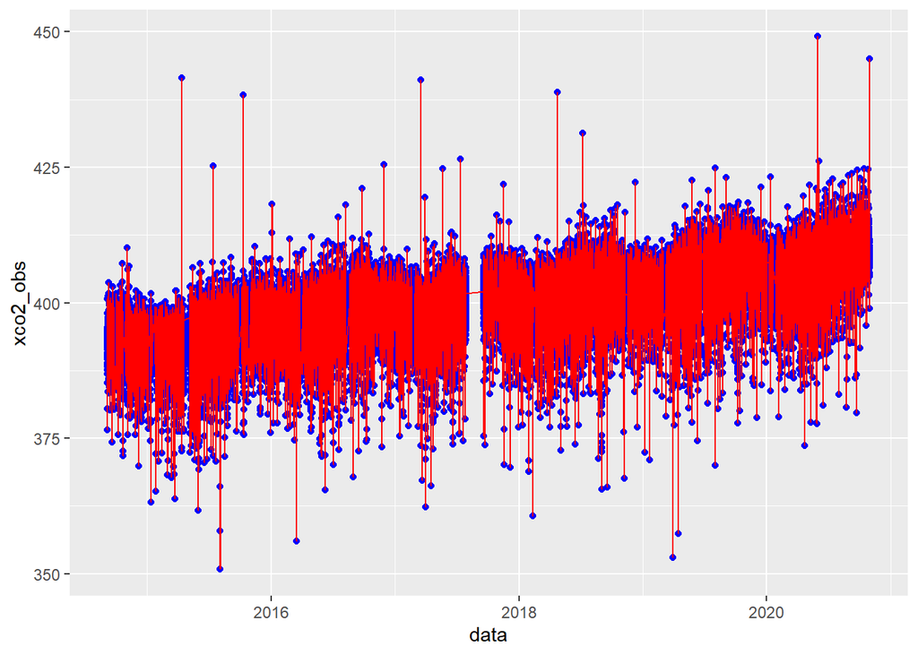

```r
oco_2 %>%
  filter(point_in_pol) %>%
  ggplot(aes(x=data,y=xco2_obs)) +
  geom_point(color="blue") +
  geom_line(color="red")
```

Agora devemos retirar a tendência ao longo do tempo, para isso, dentro do período específico, faremos a retirada por meio de um ajuste linear:

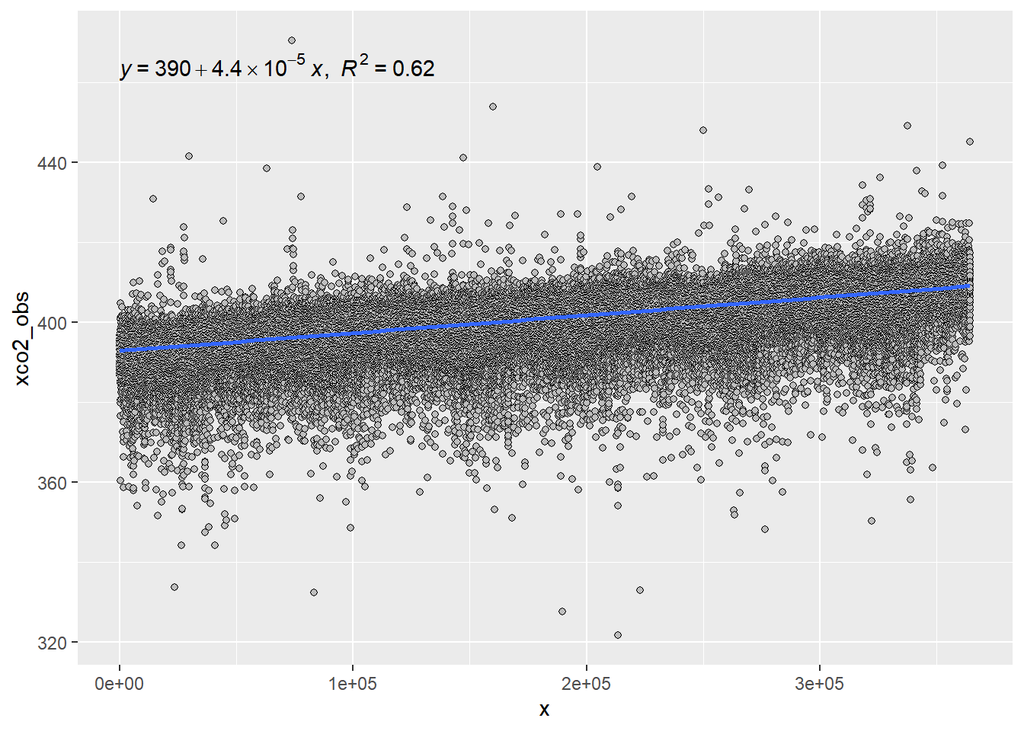

```r
oco_2 %>%
  arrange(data) %>%
  mutate(x= 1:nrow(oco_2)) %>%
  ggplot(aes(x=x,y=xco2_obs)) +
  geom_point(shape=21,color="black",fill="gray") +
  geom_smooth(method = "lm") +
  ggpubr::stat_regline_equation(aes(
  label =  paste(..eq.label.., ..rr.label.., sep = "*plain(\",\")~~")))
```

Extrair os coeficientes $a$ e $b$ da análise de regressão linear ($y = a + bX$).

```r
d_aux<-oco_2 %>%
  arrange(data) %>%
  mutate(x= 1:nrow(oco_2)) %>%
  filter(point_in_pol) %>%
  select(x,xco2_obs)
mod <- lm(d_aux$xco2_obs~d_aux$x)
summary.lm(mod)
```

```
##
## Call:
## lm(formula = d_aux$xco2_obs ~ d_aux$x)
##
## Residuals:
##     Min      1Q  Median      3Q     Max
## -51.611  -1.547   0.450   2.030  47.133
##
## Coefficients:
##              Estimate Std. Error t value Pr(>|t|)
## (Intercept) 3.931e+02  1.717e-02 22898.6   <2e-16 ***
## d_aux$x     4.353e-05  8.165e-08   533.2   <2e-16 ***
## ---
## Signif. codes:  0 '***' 0.001 '**' 0.01 '*' 0.05 '.' 0.1 ' ' 1
##
## Residual standard error: 3.307 on 147890 degrees of freedom
## Multiple R-squared:  0.6578, Adjusted R-squared:  0.6578
## F-statistic: 2.843e+05 on 1 and 147890 DF,  p-value: < 2.2e-16
```

```r
a<-mod$coefficients[1]
b<-mod$coefficients[2]
```

Criando a variável `xco2_est` a partir da retirada da tendência.

```r
oco_2 <- oco_2 %>%
  arrange(data) %>%
  mutate(
    xco2_est = a + b * as.numeric(data),
    delta = xco2_est - xco2_obs,
    XCO2 = (a-delta) - (mean(xco2_obs) - a)
  ) %>%
  glimpse()
```

```
## Rows: 364,529
## Columns: 13
## $ longitude              <dbl> -72.58572, -72.33615, -72.33615, -72.08659, ...
## $ latitude               <dbl> 6.154060, 5.157354, 5.406530, 3.163941, 3.41...
## $ time..YYYYMMDDHHMMSS.  <dbl> 2.014091e+13, 2.014091e+13, 2.014091e+13, 2....
## $ xco2..Moles.Mole...1.. <dbl> 0.000391368, 0.000389822, 0.000388482, 0.000...
## $ xco2_obs               <dbl> 391.368, 389.822, 388.482, 390.302, 386.635,...
## $ ano                    <dbl> 2014, 2014, 2014, 2014, 2014, 2014, 2014, 20...
## $ mês                    <dbl> 9, 9, 9, 9, 9, 9, 9, 9, 9, 9, 9, 9, 9, 9, 9,...
## $ dia                    <dbl> 6, 6, 6, 6, 6, 6, 6, 6, 6, 6, 6, 6, 6, 6, 6,...
## $ data                   <date> 2014-09-06, 2014-09-06, 2014-09-06, 2014-09...
## $ point_in_pol           <lgl> FALSE, FALSE, FALSE, FALSE, FALSE, FALSE, FA...
## $ xco2_est               <dbl> 393.8232, 393.8232, 393.8232, 393.8232, 393....
## $ delta                  <dbl> 2.45517575, 4.00117575, 5.34117575, 3.521175...
## $ XCO2                   <dbl> 382.8391, 381.2931, 379.9531, 381.7731, 378....
```

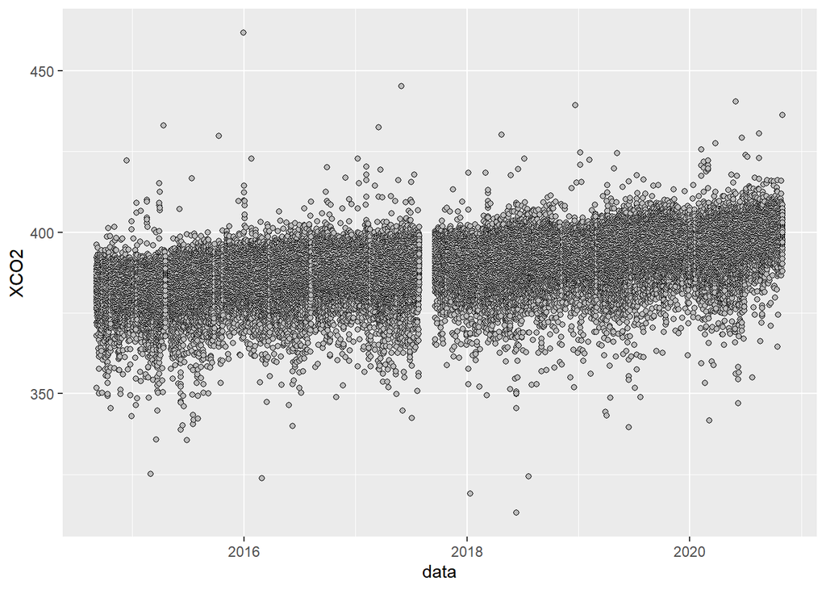

```r
oco_2 %>%
  # filter(point_in_pol) %>%
  ggplot(aes(x=data,y=XCO2)) +
  geom_point(shape=21,color="black",fill="gray")
```

Buscando os dados de duas regiões.

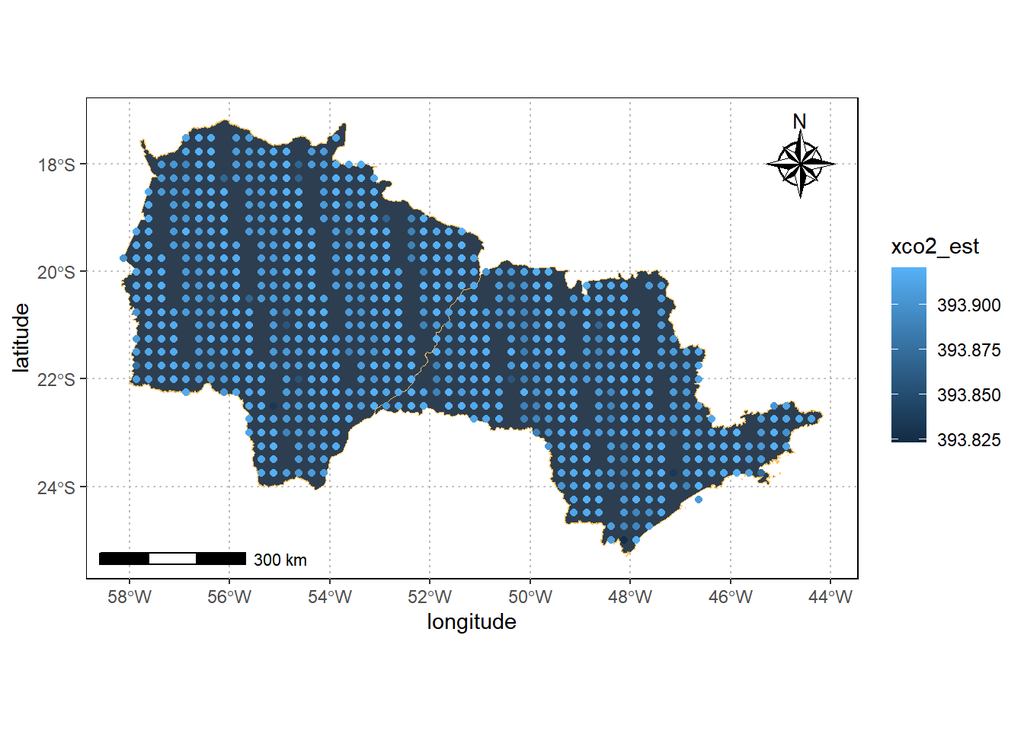

```r
# Criando o filtro
oco_2 <- oco_2 %>%
  mutate(
    point_in_pol_sp_ms = as.logical(sp::point.in.polygon(point.x = longitude,
                                      point.y = latitude,
                                      pol.x = pol_sp[,1],
                                      pol.y = pol_sp[,2])
                                    |
                                    sp::point.in.polygon(point.x = longitude,
                                      point.y = latitude,
                                      pol.x = pol_ms[,1],
                                      pol.y = pol_ms[,2]))
    )

# Plotando os dados
ggplot(sp) +
  geom_sf(fill="#2D3E50", color="#FEBF57",
          size=.15, show.legend = FALSE)+
  geom_sf(data=ms,fill="#2D3E50", color="#FEBF57",
          size=.15, show.legend = FALSE)+
  tema_mapa() +
    geom_point(data=oco_2 %>% filter(point_in_pol_sp_ms),
             aes(x=longitude,y=latitude,color=xco2_est))
```

Pronto, agora seu projeto pode continuar…